```python
%%javascript
IPython.OutputArea.prototype._should_scroll = function(lines) {
    return false;
}
```

```python
# to load images for this tutorial
from IPython.display import Image
import os
path = os.getcwd()
```

# Post Overview.

1. Introduction to independent-sample t-test.
2. Discuss the Assumptions for the independent-sample t-test.
3. Mathematics of Independent-sample t-test.
4. Demonstrate how perform a independent-sample t-test using SPSS.
5. Calculate the effect size using Cohen's.
6. Graphical Overview of Independent-sample t-test.

# Introduction to independent-sample t-test.

**Independent-sample t-test:**

- Is used to determine if a difference exists between the mean of two independent groups on a continuous numeric dependent variable.
- The t- statistic was introduced in 1908 by [William Sealy Gosset](https://en.wikipedia.org/wiki/William_Sealy_Gosset).
- The t-test can be used to determine if two sets of data are significantly different from each other.
- This test is also known as:
  - Independent t-test
  - Independent-measures t-test
  - Between-subjects t-test
  - Unpaired t-test
  - Student's t-test
- The independent t-test is the most common form of the T test
- A t test is used to determine if there is a meaningful difference between groups. It lets you know if those differences could have happened by chance.

**Example**

- - **Case** Determine if the mean salaries (in \($\)) is different between individuals that live in two neighboring zip codes (US).
  - **Zip Code Variable** would be the independent variable.
  - **Salary Variable** would be the dependent variable.
  - **Null Hypothesis \(H_{0} \):** The mean salaries for both zip codes are the same.
  - **Alternative Hypothesis \(H_{A} \):** The mean salaries for both zip codes are different (two tailed test).

**The three common case uses for independent-sample t-test Study Designs**

1. Determine if there is a difference between the two independent groups.
2. Determine if there are differences between an intervention.
3. Determine if there is a difference in change score.

**Difference between the two independent groups.**

- Is a study design that measures a dependent variable in two independent groups.
- The goal is to determine if a mean difference exist in the dependent variable between the groups.
- The participants/instances are separated into the different groups, and they are separated based on some categorical characteristic that they do not share. Example, participants are separated on whether they tested positive for Covid-19, yes or no. An individual cannot be placed in both groups. This ensures independence of observation and two independent groups.
- The independent-sample t-test would be used to calculate whether score on the dependent variable are different between the two groups. If we use the Covid-19 example, we could ask is the number of unique people they interacted with on a daily basis is different.

**Difference between an intervention.**

**Difference in change score.**

- This is a test that is used to determine if there is a difference in the dependent variable for individuals before and after a specific intervention.
- The study design would have two groups of participants/instances, and the dependent variable is measured at some baseline state before the intervention, and then measured at the end of the intervention.
- The change in score would be the difference between the baseline and end of intervention.
- Any difference between the two groups is a result of the intervention.

# Discuss the Assumptions for the independent-sample t-test.

**Assumptions**

In order to run this test, these assumptions must be considered. Failure to consider these assumptions can result in misleading and inaccurate conclusions.

- 1. You have one dependent variable that is measured on the continuous scale.
  2. You have one independent variable that consists of two categorical, independent groups.  
     **Examples:** (Male, Female), (Home run, No Home Run), (College Degree, HS Degree), Heart Disease ("Yes", "No")
  3. The study has independence of observations. There is no relationship between the participants in either groups. In the example above, people only live in one zip code and not both zip codes. Individuals are only included once.
  4. There should be no significant outliers in both groups. *Outliers are extreme data points within your sample that do no follow the pattern of the other data*.
  5. The dependent variable should be approximately normally distributed for each group of the independent variable.
  6. The variance of the dependent variable for each group of the independent variable is equal. In other words, you have homogeneity of variance.
- **Other test considerations include:**
  - You have at least 6+ participants in each group to proceed with an independent-sample t-test. You can run the with less samples but it will be harder to infer to a larger population.
  - If both groups have the same number of instances, then this is called a balanced design, if the groups have different number of instances, then this is called an unbalanced design. The greater the unbalance, then the greater the negative effect on the validity of the test.

# Mathematics of Independent-sample t-test.

**The t-test statistic**

- The test statistics for the independent-sample t-test is calculated using the following formula:  
  \[t = \frac{\bar{X_{1}} - \bar{X_{2}}}{\sqrt{\frac{s_{1}^{2}}{n_{1}} + \frac{s_{2}^{2}}{n_{2}}}} \]
- where \(\bar{X_{1}},\ \bar{X_{2}}\) are the means for the dependent variables for the independent group 1 and group 2 respectively.
- and \(s_{1}^{2},\ s_{2}^{2}\) are the estimator of common variance for the two samples and individually can be calculated using the following formula:  
  \[s^{2} = \frac{\Sigma(x - \bar{X}_{1})^{2} + \Sigma(x - \bar{X}_{2})^{2}} {n_{1} + n_{2} - 2} \]
- Once the test statistic is calculated, the t-test table needs to be consulted to obtain the critical value for the Student's t-distribution corresponding to the \(\alpha \) level of significance, typically 0.05, 0.01, or 0.001. The degree of freedom (df) must be used in the table to get the critical value, and is defined as:  
  \[df = n_{1} + n_{2} - 2 \]

**Critical Region**

- The critical region is the region of values that corresponds to the rejection of the null hypothesis at some chosen probability level (see plot below).
- The following steps are involved in the hypothesis testing process.
1. Specify the null \(H_{0} \) and alternate hypothesis \(H_{A} \).
2. Specify the level of significance \(\alpha \).
3. Calculate the test statistic.
4. Determine the critical value using the test statistic value, the degrees of freedom value, and the t-test table.
5. If the the absolute value of the t-test statistic \(|t|\) is greater than the critical value, then the difference between the two independent groups is significantly different.

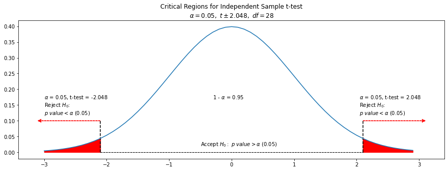

```python
import matplotlib.pyplot as plt
import numpy as np
from scipy.stats import norm

t = np.arange(-3, 3, 0.1)
T_pos = 2.048 # upper-tailed test where alpha = 0.05
T_neg = -2.048 # lower-tailed test where alpha = 0.05

plt.figure(figsize=(15,5)) # figure size
plt.plot(t, norm.pdf(t)) # plots the z curve using normal probability distribution
# fills in area where Z-test is 0.05 and above
plt.fill_between(t[t>T_pos], norm.pdf(t[t>T_pos]), color="red") # upper tail
plt.fill_between(t[t<T_neg], norm.pdf(t[t<T_neg]), color="red") # lower tail

# Plots area where Null Hypothesis is accepted
plt.text(-0.5, 0.02, r'Accept $H_{0}:\ p\ value > \alpha\ (0.05)$', fontsize=10)
plt.text(-0.3, 0.17, r'1 - $\alpha$ = 0.95', fontsize=10) # labels region where Null is accepted

# Draws dash line in region where null is accepted
plt.arrow(x=t[t>T_pos][0], y=0, dx=(t[t<T_neg][-1]-t[t>T_pos][0]), dy=0, shape='full', head_length= 0, head_width=0, length_includes_head=False, linestyle='--')

# Plots area where Null Hypothesis should be rejected

# vertical lines that indicate where to reject and accept null hypothesis
plt.vlines(t[t<T_neg][-1], 0, 0.10, colors="black", linestyle="dashed") # lower tail critical vertical line
plt.vlines(t[t>T_pos][0], 0, 0.10, colors="black", linestyle="dashed")  # upper tail critical vertical line

# Text that indicates where to reject
plt.text(T_pos, 0.12, r'Reject $H_{0}$:''\n'r'$p\ value < \alpha\ (0.05)$', fontsize=10)
plt.text(-3, 0.12, r'Reject $H_{0}$:''\n'r'$p\ value < \alpha\ (0.05)$', fontsize=10)
plt.text(T_pos, 0.17, r'$\alpha$ = 0.05, t-test = 2.048', fontsize=10)
plt.text(-3, 0.17, r'$\alpha$ = 0.05, t-test = -2.048', fontsize=10)

# Horizontal red arrowy that indicate direction to reject
plt.arrow(x=t[t<T_neg][-1], y=0.10, dx=-1, dy=0, shape='full', head_length= 0.05, head_width=0.01, length_includes_head=True, color="red", linestyle='--')
plt.arrow(x=t[t>T_pos][0], y=0.10, dx=1, dy=0, shape='full', head_length= 0.05, head_width=0.01, length_includes_head=True, color="red", linestyle='--')

# title for plot with details on test
plt.title('Critical Regions for Independent Sample t-test' '\n' r'$\alpha = 0.05,\ t \pm 2.048, \ df=28$')
plt.show()
```

## Comments

# Demonstrate how perform a independent-sample t-test using SPSS.

#### Steps

1. Review case and organize variables, and set-up hypothesis.
2. Set up data in SPSS.
3. Confirm data does not violate assumptions.
4. Carry out independent-sample t-test.
5. Interpret Results.

### Review case and organize variables, and set-up hypothesis

- **Project:** A company wants to evaluate customer engagement to two different web landings on their website. This is an A/B test, with version 1 being the current landing, and version 2, the new landing they want to test. Participants were then asked to fill in a Qualtrics survey asking to measure their engagement with the landing page. The aim is to determine which landing page will eventually yield more actions from customers.
- **Sample size:** A total of 40 participants were randomly assigned to either web landing page version 1 or version 2.
- **Independent Variable:** Web page landing version. Categorical value, version 1 or 2.
- **Dependent Variable:** User engagement score. Continuous data.
- **Goal:** Determine if there is a different in engagement scores between landing page version.
- **The Null hypothesis** \(H_{0}: \mu_{1} = \mu_{2} \): The mean engagement score for those assigned to web landing version 1 or version 2 are equal in the population.
- **The Alternative hypothesis** \(H_{A}: \mu_{1} \neq \mu_{2} \): The mean engagement score for those assigned to web landing version 1 or version 2 are not equal in the population.
- **The Level of Significance** \(\alpha = 0.05\).

### Set up data in SPSS

**SPSS Variable View**

**SPSS Data View**

- There are 40 total instances of data, with two columns, web version and engagement score.
- Web version takes on one of two values, 1 or 2, since this is categorical data and these settings are defined in the variable view.
- The engagement score (dependent variable) takes on continuous values.

[figure not shown]

```python
# Variable view
img = os.path.join(path, 'static/images/ind_sample_t_test/spss1.png')
Image(filename=img,  width = 800)
```

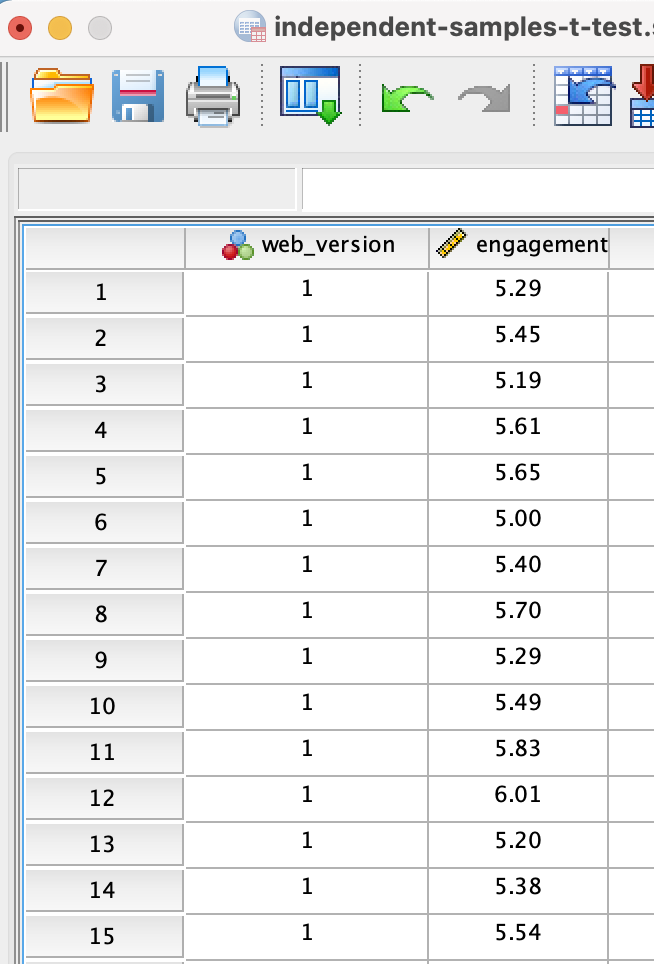

```python
# Data view
img = os.path.join(path, 'static/images/ind_sample_t_test/spss2.png')
Image(filename=img,  width = 200)
```

### Confirm data does not violate assumptions

**Why confirm assumptions?**

- A critical part of the process is confirming that the data we want to analyze meets the requirements for this model.
- If the data does not meet the models requirements, then it will provide misleading and inaccurate results.
1. Study design contains a continuous dependent variable \(\checkmark \)
   - The engagement scores takes on an value between 0 to 10.
   - The data meets the first assumption for continuous dependent variable.
2. Independent variable is categorical with two groups. \(\checkmark \)
   - In this study, our independent variable is the web page landing version.
   - We have two versions, version 1 and and version 2, and they are defined in the variable view and take on either 1 or 2 value in the data view.
   - The data meets the second assumption for an independent categorical variable with two categories.
3. Study has independence of observations. \(\checkmark \)
   - Each participant is assigned to either version 1 or 2 of the web landing page and they only provide an engagement score for the assigned landing page version. No participant is placed in both groups.
   - The data meets the third assumption for independence of observation.
4. There should be no significant outliers in the two groups of the independent variables in terms of the dependent variable. \(\checkmark \)
   - Method used **Boxplot Method**: `Analyze > Descriptive Statistics > Explore`
   - **Explore Dialogue box**: `Web landing to Factor list > Engagement to Dependent list > Click Plots`
   - **Explore: Plots Dialogue box**: `Check normality plots with tests > Un check stem-and-leaf in descriptive area > Click Continue > Return to Explore Dialogue box > Click OK`
   - The box plot generated does not indicate any outliers for both groups.
   - The data meets the assumption for not significant outliers for both groups.
5. The dependent variable should be approximately normally distributed for each group of the independent variable. \(\checkmark \)
   - Method used **Shapiro-Wilk Test**: Steps above will produce the shapiro-wilk test in the output.
   - The **Shapiro-Wilk Test** test for normality.
   - If \(p-value < \alpha (0.05)\ Reject\ H_{0} \) Data is not normally distributed, Independent-sample t-test is not the best test to use for this study design. Suggest using the Mann-Whitney U test.
   - If \(p-value > \alpha (0.05)\ Accept\ H_{0} \) Data is normally distributed, Independent-sample t-test can be used for this study design.
   - The p-value for both Version A and Version B is greater than the level of significance, suggesting that there is not enough evidence to reject the null hypothesis, and that the data comes from a normally distributed distribution.
   - The data meets the third assumption for normality. The Engagement scores for each level of web page landing were normally distributed, as assessed by Shapiro-Wilk's test (p > .05).
6. The study has homogeneity of variances. \(\checkmark \)
   - Method used **Levene's Test**: This is a test to determine if there is equal variance between two groups and SPSS returns the result of this test with the result of the Independent-Samples T Test.
   - The null hypothesis for the Levene's Test states: \(H_{0}: \sigma_{1}^{2} = \sigma_{2}^{2} \), The samples are drawn from populations with equal variances.
   - The alternative hypothesis for the Levene's Test states: \(H_{A}: \sigma_{1}^{2} \neq \sigma_{2}^{2} \), The samples are drawn from populations with variances not equal.
   - In the descriptive statistic output table, we can at minimal compare the variance for these two groups.
   - The variance for version A is 0.085 and the variance for version B is 0.155. These two numbers appear close, but the Levene's test for equality of variance will give us a more definitive response. This will be covered in the next section.
   - **Independent-Samples T Test dialogue box**: `click Ok button`
   - The data meets the assumption for equality of variance, as confirmed by the Levene's test in the next section. The p-value for the Levene's test is 0.174, which is larger than the level of significance of 0.05. Which suggest we cannot reject the null hypothesis that the groups have different variances.
   - If the test for equal variance was violated, an option would be to use the Welch t-test.

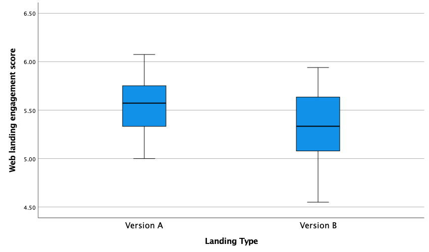

```python
# assumption 4
img = os.path.join(path, 'static/images/ind_sample_t_test/spss3.png')
Image(filename=img,  width = 700)
```

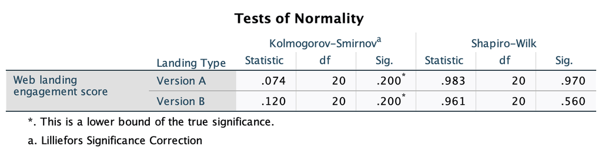

```python
# assumption 5
img = os.path.join(path, 'static/images/ind_sample_t_test/spss4.png')
Image(filename=img,  width = 800)
```

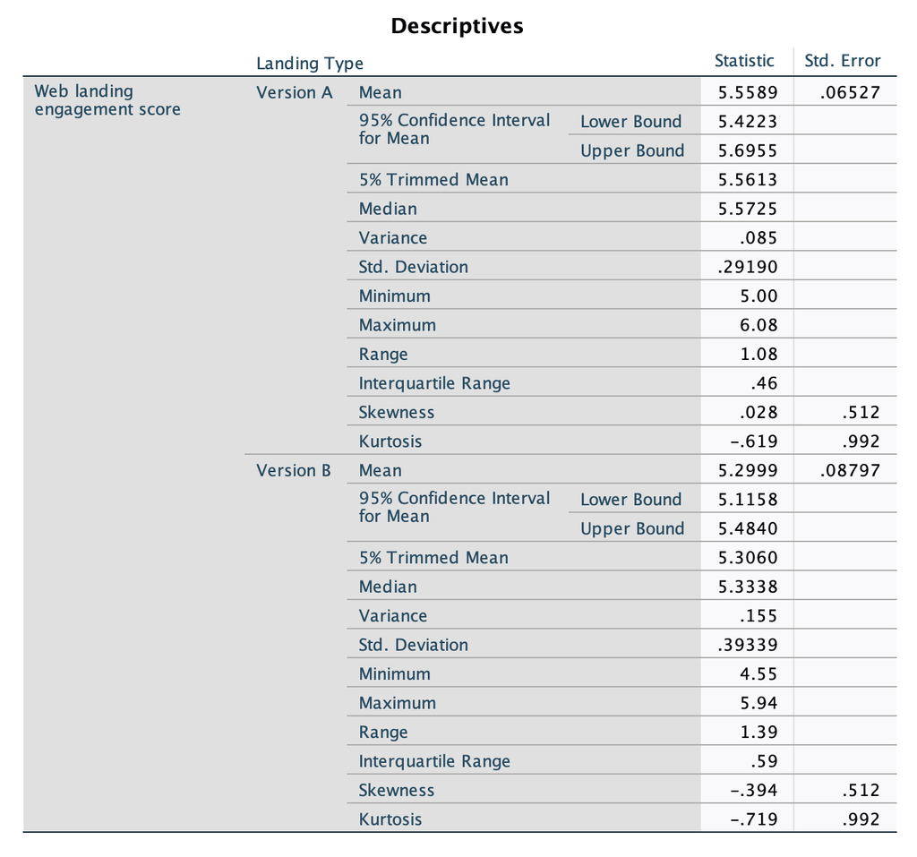

```python
# assumption 6
img = os.path.join(path, 'static/images/ind_sample_t_test/spss5.png')
Image(filename=img,  width = 800)
```

### Carry out independent-sample t-test.

**Procedure**

1. `Analyze > Compare Means > Independent-Sample T Test`
2. **Independent-Samples T Test dialogue box**: `Engagement score to Test Variable box > Web landing to Grouping Variable > click Define group`
3. **Define Groups dialogue box**: `In "Use specified values" > 1 for group 1 > 2 for group 2 > Continue`
4. **Independent-Samples T Test dialogue box**: `click Ok button`

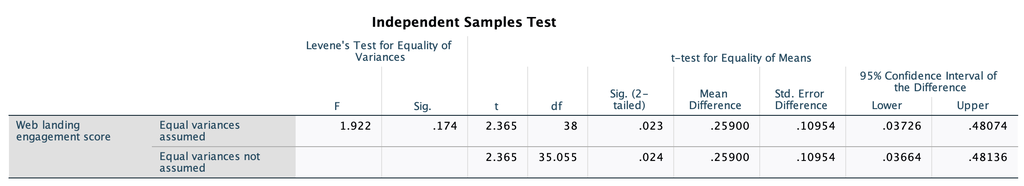

```python
img = os.path.join(path, 'static/images/ind_sample_t_test/spss6.png')
Image(filename=img, width=1000)
```

**Difference between groups.**

**Independent-sample t-test test statistic and p-value**

- The test statistic \(t = 2.365\).
- The degress of freedom (df) = \(n_{1} + n_{2} - 2 = 20 + 20 - 2 = 38\).
- The p-value for a 2-tailed test is 0.023.
- The level of significance for this test is 0.05.

### Interpret Results.

**Interpretation**

- The mean engagement score for web landing page version A was 0.26 ± 0.11 [mean ± standard error], (95% CI, 0.04 to 0.48) higher than the mean engagement score for the web landing page version B.
- There was a statistically significant difference in mean engagement score between we landing page version A and B, with web landing page version A scoring higher than B, 0.26 (95% CI, 0.04 to 0.48), t(38) = 2.365, p = .023.
- **Recommendation:** Keep using version A.

### Calculate the effect size using Cohen's d.

**Effect size**

  | Effect Size | Strength |
  | --- | --- |
  | 0.2 | Small |
  | 0.5 | Medium |
  | 0.8 | Large |

- An independent-samples t-test was run to determine if there were differences in engagement to customers that were presented with either web landing page A or B (this is an a/b test). The web page landing A was more engaging to viewers (5.56 ± 0.29) than web page landing B (5.30 ± 0.39), a statistically significant difference of 0.26 (95% CI, 0.04 to 0.48), t(38) = 2.365, p = .023, d = .75.

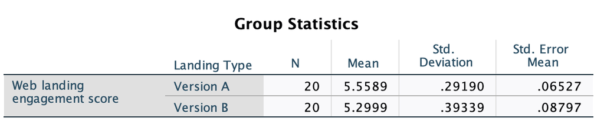

```python
img = os.path.join(path, 'static/images/ind_sample_t_test/spss7.png')
Image(filename=img, width=800)
```

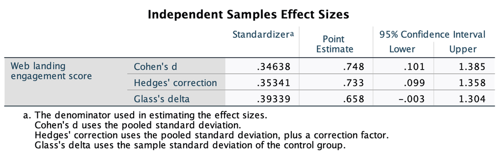

```python
img = os.path.join(path, 'static/images/ind_sample_t_test/spss8.png')
Image(filename=img, width=800)
```

# Graphical Overview of Independent-sample t-test.

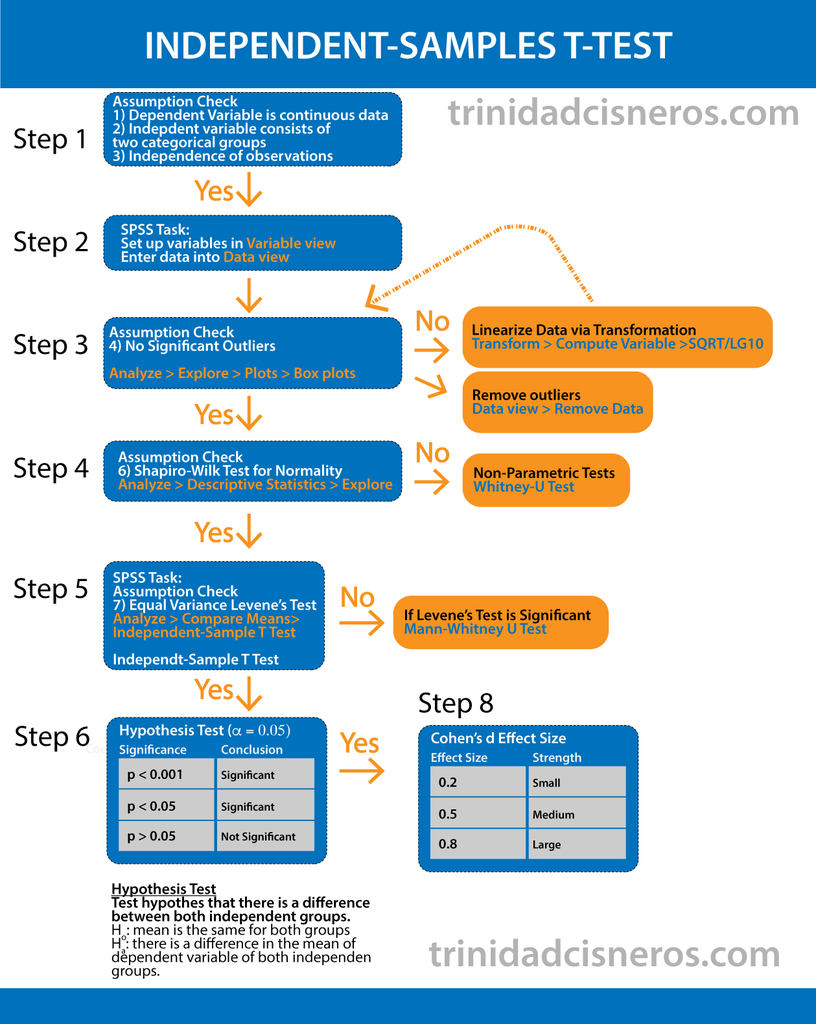

```python
img = os.path.join(path, 'static/images/ind_sample_t_test/spss9.png')
Image(filename=img, width=1000)
```